# SI 618: Data Manipulation and Analysis

## Create a stacked bar plot by using a 2-level groupby() followed by an unstack():

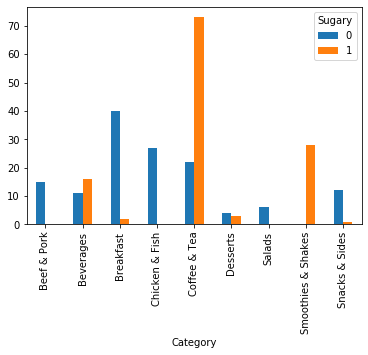

```python
menu.groupby(["Category","Sugary"]).size().unstack().plot(kind = "bar") #This will need additonal studying
```

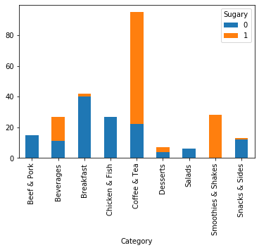

```python
menu.groupby(["Category","Sugary"]).size().unstack().plot(kind = "bar", stacked = True)
```

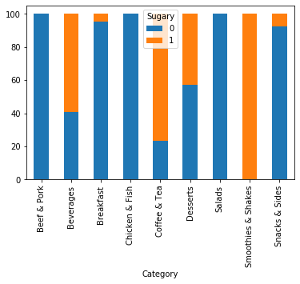

```python
menu.groupby(['Category','Sugary']).size().groupby(by='Category').apply(
    lambda x: 100 * x / x.sum()
).unstack().plot(kind='bar',stacked=True)
```

### Q6: Repeat the above steps to generate three bar plots for any other continuous variable that you split into "high" and "low" values, just as with did with "Sugars" above.

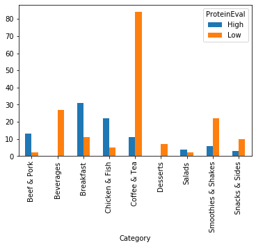

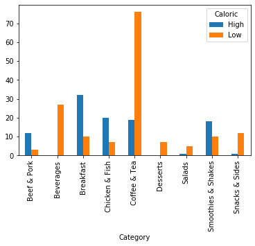

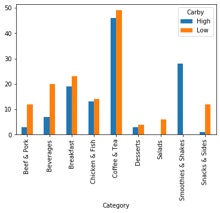

```python
# insert your code here
menu.describe()
menu["ProteinEval"] = np.where(menu["Protein"] > 15, "High", "Low")
menu.groupby(["Category","ProteinEval"]).size().unstack().plot(kind = "bar")

menu["Caloric"] = np.where(menu["Calories"] > 400, "High", "Low")
menu.groupby(["Category","Caloric"]).size().unstack().plot(kind = "bar")

menu["Carby"] = np.where(menu["Carbohydrates (% Daily Value)"] > 15, "High", "Low")
menu.groupby(["Category","Carby"]).size().unstack().plot(kind = "bar")
```

### Pie Charts

There are many issues with pie charts, and the one below is a good example of what not to do, but everyone wants to know how to make them:

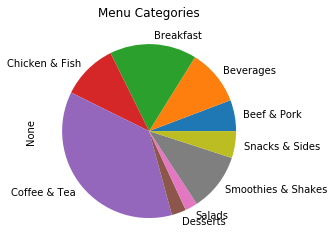

```python
# don't do this...
categories.plot(kind='pie',title='Menu Categories')
```

## Subplots (again)

In addition to the way we used subplots in the previous class, we can use the `.subplots()` function to generate mulitple plots within a figure. `subplots()` returns a set of axes on which we can make plots.

To demonstrate how this works, let's fill in just one of the subplots:

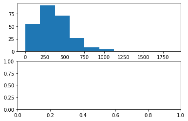

```python
f, (ax1, ax2) = plt.subplots(2) # if only 1 argument, we assume it's the number of rows
ax1.hist(menu['Calories'])
plt.show()
```

Now let's fill in both subplots:

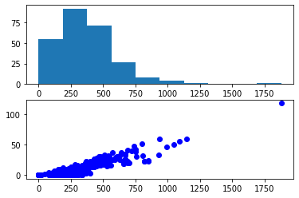

```python
f, (ax1, ax2) = plt.subplots(2)
ax1.hist(menu['Calories'])
ax2.plot(menu['Calories'],menu['Total Fat'],'bo')
plt.show()
```

Now let's make a 2x2 layout of 4 plots. Note the structure of the return values from the subplots function:

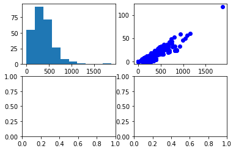

```python
f, ((ax1, ax2),(ax3,ax4)) = plt.subplots(2,2)
ax1.hist(menu['Calories'])
ax2.plot(menu['Calories'],menu['Total Fat'],'bo')
plt.show()
```

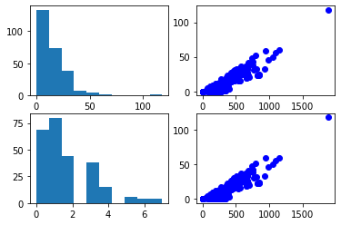

```python
f, ((ax1, ax2),(ax3,ax4)) = plt.subplots(2,2)
ax1.hist(menu['Total Fat'])
ax2.plot(menu['Calories'],menu['Total Fat'],'bo')
ax3.hist(menu['Dietary Fiber'])
ax4.plot(menu['Calories'],menu['Total Fat'],'bo')
plt.show()
```

Alternatively, we can use the pandas-matplotlib integration. Note the use of the `ax=` keyword arg.

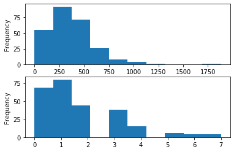

```python
f, (ax1, ax2) = plt.subplots(2)
menu['Calories'].plot(ax=ax1, kind='hist')
menu['Dietary Fiber'].plot(ax = ax2,kind='hist')
plt.show()
```

### Q7: Use subplots() to create a figure consisting of 4 plots.

They could be scatter plots, histograms, bar charts, pie plots, or any of the kinds (repeated here for your convenience):

```
kind :
- 'line' : line plot (default)
- 'bar' : vertical bar plot
- 'barh' : horizontal bar plot
- 'hist' : histogram
- 'box' : boxplot
- 'kde' : Kernel Density Estimation plot
- 'density' : same as 'kde'
- 'area' : area plot
- 'pie' : pie plot
```

```python
# insert your code here
```

### [xkcd](https://xkcd.com/1838/) style plots (just for fun)

Note that we can scope the use of any `plt.` function by using a `with` statement.

Note also that we can save a figure as a file by using `savefig(...)` (as shown below).

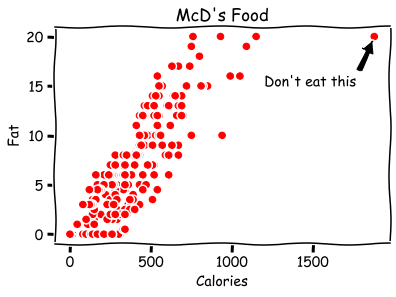

```python
with plt.xkcd():
        # This figure will be in XKCD-style
        plt.plot(menu["Calories"],menu["Saturated Fat"],'ro')
        plt.title("McD's Food")
        plt.xlabel('Calories')
        plt.ylabel('Fat')
        plt.annotate("Don't eat this",xytext=(1200,15),xy=(1880,20),arrowprops=dict(facecolor='black', shrink=0.1))
        plt.savefig('xkcd.png',format='png') # alternatively, we could save as a pdf, svg, ps, or eps
        plt.show()
```

### Q8: Create an xkcd-style plot of any of the previous plots you created. Make sure you annotate it with at least one interesting feature.

**Share your saved figure on the Slack #general channel**.

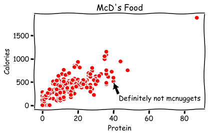

```python
# insert your code here
with plt.xkcd():
        # This figure will be in XKCD-style
        plt.plot(menu["Protein"],menu["Calories"],'ro')
        plt.title("McD's Food")
        plt.xlabel('Protein')
        plt.ylabel('Calories')
        plt.annotate("Definitely not mcnuggets",xytext=(43,100),xy=(40,500),arrowprops=dict(facecolor='black', shrink=0.05))
        plt.tight_layout()
        plt.savefig('xkcd.png',format='png') # alternatively, we could save as a pdf, svg, ps, or eps
        plt.show()
```

## Simple (univariate) statistics

```python
# The weights of a herd of 80 cows
# Fixing random state for reproducibility
np.random.seed(618)

measures = (np.random.standard_normal(80)*150+1000).astype(int) #80 cows, standard deviation, on average around 1000lbs that get converted to int
measures
```

```
array([1167, 1075,  893, 1066, 1025, 1084,  665, 1021, 1085,  886, 1161,
        959, 1008, 1004,  953, 1050, 1091,  857,  881,  891, 1048, 1213,
       1094, 1031,  935, 1014, 1054,  933, 1053, 1026,  844,  996, 1115,
        836,  884,  901,  801, 1226, 1091, 1448, 1119, 1215, 1199, 1030,
       1163,  987,  925, 1127, 1108, 1146, 1400,  984, 1035,  841, 1015,
        922, 1042, 1026,  888,  987,  933,  850, 1237, 1018,  955, 1308,
        817, 1146, 1022,  884, 1200,  979,  787, 1056, 1105, 1101, 1054,
       1285,  770,  710])
```

```python
# equivalently
# Fixing random state for reproducibility
np.random.seed(618)

measures = (np.random.normal(1000,150,80)).astype(int)
measures
```

```
array([1167, 1075,  893, 1066, 1025, 1084,  665, 1021, 1085,  886, 1161,
        959, 1008, 1004,  953, 1050, 1091,  857,  881,  891, 1048, 1213,
       1094, 1031,  935, 1014, 1054,  933, 1053, 1026,  844,  996, 1115,
        836,  884,  901,  801, 1226, 1091, 1448, 1119, 1215, 1199, 1030,
       1163,  987,  925, 1127, 1108, 1146, 1400,  984, 1035,  841, 1015,
        922, 1042, 1026,  888,  987,  933,  850, 1237, 1018,  955, 1308,
        817, 1146, 1022,  884, 1200,  979,  787, 1056, 1105, 1101, 1054,
       1285,  770,  710])
```

### Q9: Create some objects of your own

Think of some object and some property of that object. I used cows and their weights. Pick something that you know something about, and create a NumPy array of some number of them (ideally between 20 and 1000), recording some property. So you might choose something like the height of undergraduate students, etc. Pick somethink that will *likely* have a normal distribution (which is probably most things you can think of.</font>

First, pick the number that you want and assign it to numberOfObjects, then pick the mean value and assign it to meanOfProperty, and finally pick the variance and assign it to varianceOfProperty. It doesn't matter what you pick, but if you're unsure pick 1/5 of the mean.

```python
numberOfObjects = 150    # change np.NaN to some number between 20 and 50000
meanOfProperty = 140     # change np.NaN to the mean value of the property you're interested in
standardDeviationOfProperty = meanOfProperty/5 # change np.NaN to the variance of the property -- try meanOfProperty/5 if you have no idea
```

Now create some data by asking for a random sample from a normal distribution, scaled so that it matches the mean and variance you want:

```python
things = np.random.standard_normal(numberOfObjects)*standardDeviationOfProperty+meanOfProperty
# And let's say we want integers instead of floats:
things = things.astype(int)
things
```

```
array([142, 124, 150, 128, 124, 143, 149,  94, 143, 104,  93, 129, 132,
       139, 179, 197, 156, 143,  98, 115, 165, 160, 102, 132, 178, 124,
       105, 160, 100, 162, 157, 116, 142, 124, 157, 192, 105, 161, 142,
       171,  94, 168, 162, 130, 197, 134, 176,  97, 118, 142,  82, 101,
       122, 142, 126, 113, 107, 111, 116, 165, 131, 114, 143, 150,  78,
        96, 174, 138, 198, 186, 169, 157, 166, 148, 124, 108, 143, 129,
       145, 170, 154, 164, 136, 136, 134, 130,  95, 201, 142, 140, 155,
       135, 114, 145, 160, 118, 142, 128, 137, 138, 134, 125, 137, 183,
       112, 138, 142,  97, 117, 146,  85, 106, 177, 181, 142, 143, 143,
       172, 119, 152, 138, 144, 117, 115, 135, 166, 129, 118,  88, 122,
       111, 117, 164, 118, 145, 160, 166, 138, 102,  79, 128, 148, 132,
        59, 173, 189, 149, 129, 108, 127])
```

## Measures of central tendency

- Mean
- Median
- Mode

## Mean

Add up all the values and divide by the number of values:

$$mean = \frac {\sum{x_i}} {n}$$

```python
sum(measures)/len(measures)
```

```
1021.7625
```

```python
np.mean(measures) # find the mean
```

```
1021.7625
```

## Median

sort all the numbers and find the one in the middle

```python
measures = np.sort(measures)
measures
```

```
array([ 665,  710,  770,  787,  801,  817,  836,  841,  844,  850,  857,
        881,  884,  884,  886,  888,  891,  893,  901,  922,  925,  933,
        933,  935,  953,  955,  959,  979,  984,  987,  987,  996, 1004,
       1008, 1014, 1015, 1018, 1021, 1022, 1025, 1026, 1026, 1030, 1031,
       1035, 1042, 1048, 1050, 1053, 1054, 1054, 1056, 1066, 1075, 1084,
       1085, 1091, 1091, 1094, 1101, 1105, 1108, 1115, 1119, 1127, 1146,
       1146, 1161, 1163, 1167, 1199, 1200, 1213, 1215, 1226, 1237, 1285,
       1308, 1400, 1448])
```

```python
measures[len(measures)//2]  # find middle value
```

```
1026
```

```python
np.median(measures)
```

```
1025.5
```

## Another alternative: Mode

- mode = most common value
- Unfortunately not in default numpy

```python
from scipy import stats
stats.mode(measures)
```

```
ModeResult(mode=array([884]), count=array([2]))
```

### Q10: Calculate the mean, median and mode of your "things"

Step 1: Just run the following cell (assumes you have some data in an np array called "things")

```python
from scipy import stats # just in case we didn't already do it

thingsMean = np.mean(things) # replace 0 with your code
thingsMedian = np.median(things) # replace 0 with your code
thingsMode = stats.mode(things) # replace 0 with your code

print(thingsMean, thingsMedian, thingsMode)
```

```
136.50666666666666 137.5 ModeResult(mode=array([142]), count=array([9]))
```

Step 2: Now, to demonstrate what happens to mean, median and mode when you add an outlier, append some crazy big value to the end of your things. But let's not mess up our things array, so let's copy it first

```python
outliers = 999999999 # change np.nan to some extreme value

things2 = things.copy()
things2 = np.append(things2,outliers)
things2Mean = np.mean(things2).round(2)
things2Median = np.median(things2)
things2Mode = stats.mode(things2)[0].item()

print(things2Mean, things2Median, things2Mode)
```

```
6622652.15 138.0 142
```

Step 3: Record, in your own words, what happened to each of the mean, median and mode when you added that value:

The mean was pulled upwards heavil. The median and mode did not change very much because they are less sensitive to outliers

## Measures of dispersion

- Percentile cutoffs
  - Interpercentile range
- Variance
- Standard Deviation

## Percentiles

- In a *sorted* list, find the threshold so that data is split
  - 5th percentile -- bottom 5% of measures below threshold
  - 25th percentile -- bottom 25% of measures below
  - 97th percentile -- bottom 97% of mesures below

## Numpy does this well

```
np.percentile(array,percentile,
               interpolation='linear')
```

```python
np.percentile(measures,25) # the 25th percentile
```

```
924.25
```

```python
np.percentile(measures,25,interpolation='higher') # bump it up to the next higher real value from the data
```

```
925
```

## Interpercentile Range

- Sometimes we want to some range
  - e.g., 5th -- 95th percentile: 90% of measures sit here

```python
print(np.percentile(measures,5),"-",np.percentile(measures,95))
```

```
800.3000000000001 - 1239.3999999999999
```

## Variance

How does the data spread around the mean?

$$ variance = \frac{\sum{(x_i - \mu)^2}}{n}$$

where, $\mu$ is the mean

$$ mu = \frac{\sum{x_i}}{n}$$

## Standard Deviation

- Measure of dispersion

[figure not shown]

```python
print(np.percentile(measures,2.5),"-",np.percentile(measures,97.5))
print(np.var(measures))
print(np.std(measures))  # this should be the square root of variance
```

```
768.5 - 1310.2999999999993
20879.33109375
144.4968203586155
```

### Q11: Measures of dispersion

Examine the 2.5-97.5 percentile range and the standard deviation of your "things". Does the output for standard deviation match what you asked for when you first generated the data above? What's the relationship between the 2.5th-to-97.5th percentile range and the standard deviation? Answer below

```python
# insert your code here
print(np.percentile(things,2.5),"-",np.percentile(things,97.5))
print(np.std(things))

193.375 - 84.175
109.2/27.43
```

```
84.175 - 193.37500000000003
27.43616753281859
```

```
3.9810426540284363
```

## Visualizing data with Seaborn

- Visualization package built on top of matplotlib
- It's meant to make your life better
- Plays well with pandas, numpy, scipy, and statsmodels
- Many different visualization are included:
  - Strip plots, Swarm plots, Violin plots
  - Box plots
  - Histograms

  We need to import the package, and it's typically imported as sns:

  ```
  import seaborn as sns
  ```

  and don't forget to inline matplotlib (that's a jupyter thing):

  ```
  %matplotlib inline
  ```

seaborn.pydata.org

## Seaborn versus Matplotlib

- Matplotlib
  - Low-level, basis for many packages
  - Painful to construct certain graphs
  - Not Pandas friendly
  - Not interactive
- Seaborn
  - Pandas friendlier
  - Great for some stats plots

```python
import seaborn as sns
```

## Strip Plot

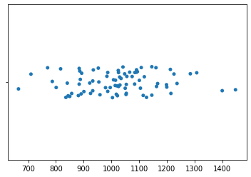

```python
%matplotlib inline
import seaborn as sns  # you might need to do: conda install seaborn
sns.stripplot(x=measures) #takes the values across the x axis and creates a jittered dot plot so you can see their distribution
```

## Swarm Plot

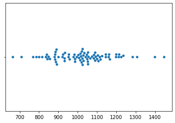

```python
sns.swarmplot(x=measures) #Groups values together and spreads them out to the right. Not commonly used
```

## Violin Plot

- If we have too much data

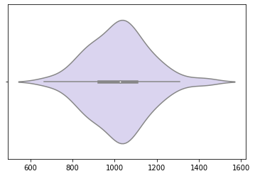

```python
sns.violinplot(x=measures,color="#d7d0f3") #Combination of multiple plots. A smoothed histogram with an embedded boxplot
#Can be mirrored or use a different dataset for the other side
```

## Box Plot

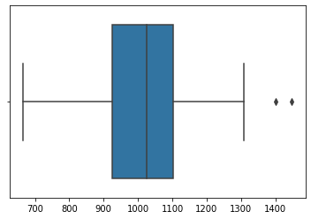

```python
sns.boxplot(x=measures)
```

And we can manipulate the underlying plot to control different features. See https://stackoverflow.com/questions/34162443/why-do-many-examples-use-fig-ax-plt-subplots-in-matplotlib-pyplot-python#34162641 and https://matplotlib.org/api/pyplot_api.html#matplotlib.pyplot.subplots for explanations about `plt.subplots()`

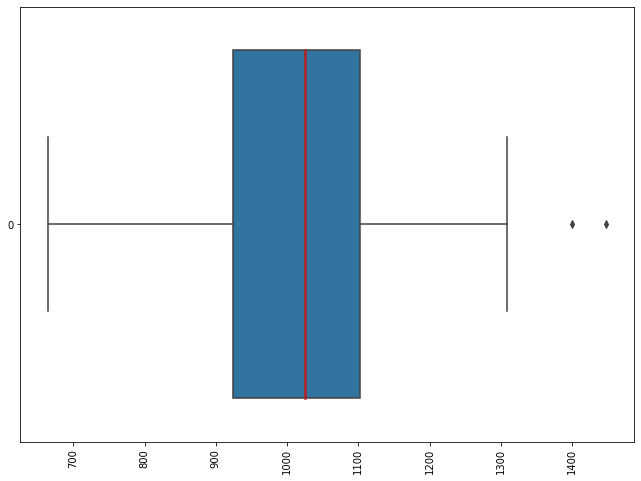

```python
import matplotlib.pyplot as plt
fig, ax = plt.subplots()
fig.set_size_inches(11, 8)
medianprops = dict( linewidth=2.5, color='firebrick')
sns.boxplot(medianprops=medianprops,data=measures,orient='h')
plt.xticks(rotation=90)
```

## Histogram

We're going to use this a lot. Seaborn puts a nice smooth line over a distribution. We'll talk about that soon, but for now just think about it as an extrapolation: if we had a bunch more data, the distribution would eventually smooth out to something that looks like the line.

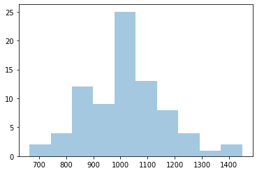

```python
# x axis = value, y axis = count (frequency)
sns.distplot(measures, kde=False); #Kernel density estimate based upon an infinite set of data and this distribution
```

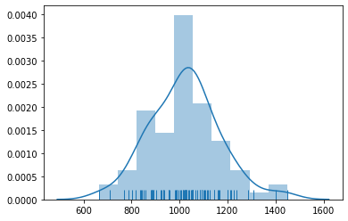

```python
sns.distplot(measures, rug=True); # show a strip plot on bottom -- we call it a "rug"
```

### Q12: Test driving Seaborn

Your turn: create the above plots (strip, swarm, violin, box, and histogram for your "things".

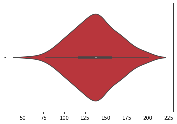

```python
sns.violinplot(x=things,color="#ce2029")
```

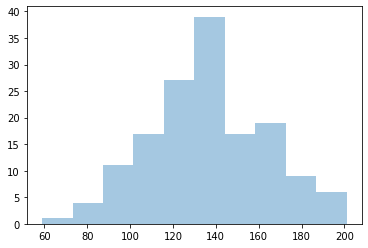

```python
sns.distplot(things, kde=False);
```

Chose two plots from the ones you generated above and in your own words explain what each of them tells you about your data.

From these plots, we can see that the majority of values cluster around the 140 mark and that they follow an approximately normal distribution.

## Visualizing the menu data using Seaborn

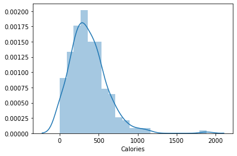

```python
sns.distplot(menu.Calories)
```

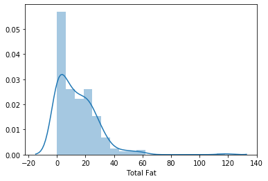

```python
sns.distplot(menu['Total Fat'])
```

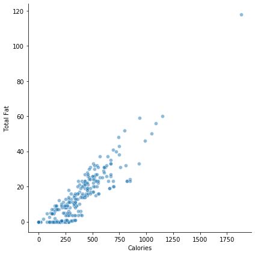

```python
# Relationship between petal_width & petal_length by species
sns.relplot(x="Calories", y="Total Fat",# hue="Category",
            sizes=(40, 400), alpha=.5,
            height=6, data=menu)
```

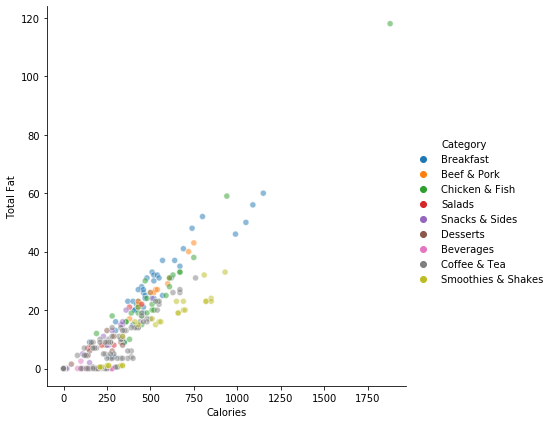

```python
# Relationship between petal_width & petal_length by species
sns.relplot(x="Calories", y="Total Fat",hue="Category",
            sizes=(40, 400), alpha=.5,
            height=6, data=menu)
```

```python
sns.jointplot(x='Calories',y='Total Fat',data=menu)
```

[output not shown]

It's a bit difficult to see where the interesting areas in the plot are, so it's worth trying a hexbin plot. Go ahead and copy the above code block and add `kind="hex"` to the jointplot parameters.

```python
# insert your code here
```

Now, take a look at what happens when you set `kind="kde"`

```python
sns.jointplot(x='Total Fat',y='Calories',kind="kde",data=menu)
```

[output not shown]

Finally, you may want to look at all the numeric variables in your dataset. Use `pairplot` to do this:

```python
sns.pairplot(menu.query("Category == 'Breakfast'"),vars=['Calories','Total Fat','Protein','Dietary Fiber'])
```

[output not shown]

We can get fancier by using a different column to set the color (or "hue"):

Try running the following code:

```python
sns.pairplot(menu,hue="Category",vars=['Calories','Total Fat','Protein','Dietary Fiber'])
```

[output not shown]

Now let's introduce some correlations. We're not going to spend time on learning about the theory behind correlation, as you've done that in the statistics prerequisite for this course. Instead, we're going to jump right in and annotate a graph with a lot of statistical information:

```python
from scipy import stats
```

```python
# ignore the warning about deprecated annotation
g = sns.JointGrid(data=menu,x='Protein',y='Dietary Fiber')
g = g.plot(sns.regplot, sns.distplot)
g = g.annotate(stats.pearsonr)
```

[output not shown]

## Why do we care about distributions?

## World is not normal

- Many other kinds of distributions
- We can tell what they are by looking at distribution

## Uniform

```python
uniform = np.random.uniform(-2,2,1000)  # low,high,count
sns.distplot(uniform,kde=False,norm_hist=False)
```

[output not shown]

## Bimodal

```python
bimodal = np.append(np.random.normal(-20,10,100),
                    np.random.normal(20,10,100))
sns.distplot(bimodal,kde=False,norm_hist=True)
```

[output not shown]

# Poisson

$$ P(k~events~in~interval) = \frac{\lambda^ke^{-\lambda}}{k!} $$

$\lambda$ is the event rate

Examples

- Meteor strikes
- Arrival of patients to hospital

```python
# as lambda goes up --> looks more normal
pois = np.random.poisson(3,100000) # lambda, count
sns.distplot(pois,kde=False,bins=10,norm_hist=True)
```

[output not shown]

# Power/Zipf/Pareto

$$ P = \frac{x^{-a}}{\zeta(a)}$$

"long tail"

- degree distribution
- movie/music popularity
- words

```python
power = np.random.zipf(2,100000)
sns.distplot(np.log(power),kde=False)
```

[output not shown]

## Visual Tests on Data

```python
testdata = (np.random.standard_normal(500)*20+150).astype(int)
sns.distplot(testdata)
```

[output not shown]

## Run Sequence

- Run Sequence (index versus value)
- flat and non-drifting
  - fixed-location assumption holds
- vertical spread same over the entire plot,
  - then the fixed-variation assumption holds.

```python
ax = sns.regplot(np.arange(len(testdata)),testdata,fit_reg=False)
ax.set_ylim(0,250)
ax.set_ylabel("val")
ax.set_xlabel("i")
```

[output not shown]

```python
drifting = np.array([testdata[i]+i*(.1) for i in np.arange(len(testdata))])
sns.distplot(drifting,kde=False)
```

[output not shown]

```python
ax = sns.regplot(np.arange(len(drifting)),drifting,fit_reg=False)
ax.set_ylim(0,300)
ax.set_ylabel("val")
ax.set_xlabel("i")
```

[output not shown]

```python
expanding = np.array([(testdata[i]+i*np.random.randint(-1,1)*.2)
                     for i in np.arange(len(testdata))])
sns.distplot(expanding,kde=False,norm_hist=True)
```

[output not shown]

```python
ax = sns.regplot(np.arange(len(expanding)),expanding,fit_reg=False)
ax.set_ylim(0,300)
ax.set_ylabel("val")
ax.set_xlabel("i")
```

[output not shown]

# Lag Plot

- Plot point $y_i$ versus $y_{i-1}$
- If the lag plot is structureless
  - randomness assumption holds.

```python
lag = testdata.copy()
lag = np.array(lag[:-1])
current = testdata[1:]
ax = sns.regplot(current,lag,fit_reg=False)
ax.set_ylabel("y_i-1")
ax.set_xlabel("y_i")
```

[output not shown]

```python
connected = np.array([testdata[i]+testdata[i-1] for i in np.arange(500)])
sns.distplot(connected,kde=False,norm_hist=True)
```

[output not shown]

```python
lag = connected.copy()
lag = np.array(lag[:-1])
current = connected[1:]
ax = sns.regplot(current,lag,fit_reg=False)
ax.set_ylabel("y_i-1")
ax.set_xlabel("y_i")
```

[output not shown]

## QQ Plot

- QQ Plots takes our n ordered data points
  - sorted from smallest to largest
- Asks:
  - What is the relationship between quantiles from our data and quantiles from a theoretical distribution that we're assuming the sample is drawn from

```python
qntls, xr = stats.probplot(testdata, fit=False)
sns.regplot(xr,qntls)
```

[output not shown]

```python
def random_snorm(n, mean = 0, sd = 1, xi = 1.5):
    def random_snorm_aux(n, xi):
        weight = xi/(xi + 1/xi)
        z = np.random.uniform(-weight,1-weight,n)
        xi_ = xi**np.sign(z)
        random = -np.absolute(np.random.normal(0,1,n))/xi_ * np.sign(z)
        m1 = 2/np.sqrt(2 * np.pi)
        mu = m1 * (xi - 1/xi)
        sigma = np.sqrt((1 - m1**2) * (xi**2 + 1/xi**2) + 2 * m1**2 - 1)
        return (random - mu)/sigma

    return random_snorm_aux(n, xi) * sd + mean
```

```python
rightskewed = random_snorm(1000,xi=2)*100
sns.distplot(rightskewed,kde=False)
```

[output not shown]

```python
qntls, xr = stats.probplot(rightskewed, fit=False)
sns.regplot(xr,qntls)
```

[output not shown]

```python
leftskewed = random_snorm(1000,xi=-2)*100
sns.distplot(leftskewed,kde=False)
```

[output not shown]

```python
qntls, xr = stats.probplot(leftskewed, fit=False)
sns.regplot(xr,qntls)
```

[output not shown]

## Now the serious plots... let's wrap them in a single function that we can call

```python
def multiplePlots( series ):

    fig, axs = plt.subplots(2,2)
    plt.tight_layout(pad=0.4, w_pad=4, h_pad=1.0)

    # Histogram
    sns.distplot(series, ax=axs[0,0])

    # Lag plot
    lag = series.copy()
    lag = np.array(lag[:-1])
    current = series[1:]
    ax = sns.regplot(current,lag,fit_reg=False, ax=axs[0,1])
    ax.set_ylabel("y_i-1")
    ax.set_xlabel("y_i")

    # QQ plot
    qntls, xr = stats.probplot(series, fit=False)
    sns.regplot(xr,qntls, ax=axs[1,0])

    # Run sequence
    ax = sns.regplot(np.arange(len(series)),series, ax=axs[1,1])
    ax.set_ylabel("val")
    ax.set_xlabel("i")
```

## Now run this on your "things"

```python
multiplePlots(things)
```

[output not shown]

### Q13: [Do your data look](https://www.theguardian.com/news/datablog/2010/jul/16/data-plural-singular) normally distributed?

Explain why or why not.

### Q14:

You should first load the CSV file into a DataFrame, then look at various aspects of **each** variable.

**Your responses should consist of code cells, as well as markdown cells that state something like:**

> Variable v99 appears to be drawn from a uniform distribution with mean X and standard deviation Y.  
> A histogram of the data appears to be... The QQ plot shows....

```python
# ignore code below
```

```python
# answer to Q5 above
menu['Sugary'] = np.where(menu['Sugars'] > 20, 1 , 0)
```

```python
# lecture helper
things = measures.copy()
```